# Loan Default Prediction — Full Code Capstone

**Author:** Trinidad Cisneros **Program:** MIT Professional Education, Applied Data Science Program **Dataset:** HMEQ (Home Equity) **Problem type:** Supervised binary classification **Primary metric:** Recall on class 1 (defaulters). Tie breaker: F1 on class 1. Secondary diagnostic: ROC AUC.

This notebook predicts whether a home equity loan applicant will default (`BAD = 1`) or pay as agreed (`BAD = 0`). We compare fifteen supervised classifiers side by side and recommend the best one for the bank to put into production.

Every method section follows the same layout so you can jump between them: a plain language description of the method, how we fit it, how it performed on the test set, its diagnostics charts, and a one paragraph interpretation.

**Part A — Problem and Data**

1. Problem Definition
2. Data Description
3. Setup and Imports
4. Load and Inspect Data
5. Summary Statistics

**Part B — Exploratory Data Analysis** 6. Univariate Analysis 7. Bivariate Analysis 8. Multivariate Analysis 9. EDA Takeaways

**Part C — Data Preprocessing** 10. Outlier Treatment 11. Missing Value Treatment 12. Encoding and Scaling 13. Train Test Split

**Part D — Modeling (fifteen classifiers)** 14. Modeling Approach and Helper Functions 15. Logistic Regression 16. K Nearest Neighbors 17. Naive Bayes 18. Linear Discriminant Analysis 19. Quadratic Discriminant Analysis 20. Decision Tree 21. Random Forest 22. Bagging Classifier 23. AdaBoost 24. Gradient Boosting 25. XGBoost 26. LightGBM 27. CatBoost 28. Support Vector Machine 29. Neural Network (MLP)

**Part E — Comparison and Recommendation** 30. Side by Side Model Comparison 31. Final Recommendation 32. Implementation Recommendations

**Executive Summary**

- Executive Summary

## Executive Summary

### Important Findings

**Objective**

- This project evaluated 15 classification models on the HMEQ dataset (5,960 home equity loan applicants, ~20% default rate) to predict loan default and recommend an automated underwriting solution.

**Findings**

### Final Proposed Model

**Champion: CatBoost** with `depth=5, learning_rate=0.03, iterations=500, class_weights=[1, 4.01]`

**Why CatBoost over the alternatives**

- CatBoost was selected over XGBoost (79.8% recall) and LightGBM (79.5% recall) because it leads on the primary metric while handling categorical features (JOB, REASON) natively and producing the most balanced feature importance profile across DEBTINC, CLAGE, JOB, VALUE, and DELINQ.
- **Strong alternative — LightGBM:** if the business prioritizes minimizing false alarms over maximizing default detection, LightGBM leads on F1 (0.818), accuracy (92.95%), and ROC AUC (0.967) with only 44 false positives. It is the recommended model for probability based risk scoring and tiering.

### Key Next Steps

- **Deploy CatBoost behind a scoring API** using its native `save_model()` format, returning both the predicted class and the default probability so credit analysts can set approval thresholds for borderline cases.
- **Threshold optimization:** sweep the decision threshold away from the default 0.50 to the point that maximizes recall at a target false positive rate (Section 32 details this). Even without retraining, threshold tuning yields significant uplift.
- **Monitor for drift:** track DEBTINC missingness rate, feature distributions, and weekly recall in production. Trigger a retrain if DEBTINC missingness drops below 10% or recall falls below 70%.
- **Fair lending audit:** run bias testing on proxy variables (JOB ranks in CatBoost's top three features) and generate per applicant SHAP explanations for regulatory compliance.
- **Maintain a champion/challenger framework:** keep LightGBM as the challenger and compare weekly on incoming applications.

### Follow Up Study: Business Loss Function Analysis

- A companion study, [Beyond Recall: How Business Loss Functions Change Which Model Wins](https://trinidadcisneros.com/folders/ds_blogs/ds_loan_default_business_loss.html), extended this work by retraining all 15 models under three optimization frameworks: recall, asymmetric cost sensitive (weighting a missed default at USD 9,304 versus a rejected good loan at USD 4,466), and profit based.
- **Central finding:** CatBoost remains the top model across all three frameworks, but its optimal configuration changes — the profit optimized variant (depth=7, learning_rate=0.08) generates USD 3.95M in estimated portfolio profit on the test set compared to USD 3.90M for the recall optimized variant, while maintaining 79.5% recall.
- This confirms that the recall first approach used in this capstone identifies the right model family, and that further gains are available through business aligned threshold and objective tuning in production.

## 1. Problem Definition

### 1.1 Context

Banks make a lot of their profit from home loans, and they lose a lot of money when those loans go bad. Today most approval decisions are made by a loan officer reading the application by hand, which is slow, expensive, and open to inconsistency. The bank wants a model that can scan an application and flag the risky ones automatically, so the human review time is spent on the cases that actually need it.

### 1.2 Objective

Build a classification model that predicts whether a home equity loan applicant is likely to default, and identify which features the bank should pay the most attention to during underwriting.

### 1.3 Key Questions

- Which applicant features separate defaulters from non defaulters the most?
- Which modeling approach gives the bank the highest catch rate on defaulters without rejecting too many good applicants?
- How interpretable does the model need to be, given that lending decisions must comply with fair lending rules (Equal Credit Opportunity Act)?
- How should the bank translate the model's score into an approve, reject, or manual review decision?

### 1.4 Data Science Formulation

This is a **supervised binary classification problem**. The label `BAD` is known for every row (1 = defaulted, 0 = paid as agreed), so we train on past decisions and predict the label on new applicants.

### 1.5 Measure of Success

**Primary metric: Recall on class 1 (defaulters).** In lending the cost of approving a defaulter is much higher than the cost of rejecting a good applicant, so we want to catch as many bad loans as we can. We use F1 on class 1 as the tie breaker to keep precision from collapsing, and we report ROC AUC as a secondary diagnostic.

## 2. Data Description

The HMEQ dataset contains 5,960 home equity loan applicants. Each row is one applicant, the target is `BAD`, and there are 12 input features covering loan details, job information, and credit history.

| Column | Type | Meaning |
| --- | --- | --- |
| `BAD` | binary target | 1 if the applicant defaulted or became seriously delinquent, 0 if the loan was paid |
| `LOAN` | numeric | Dollar amount of the loan approved |
| `MORTDUE` | numeric | Amount still owed on the applicant's existing mortgage |
| `VALUE` | numeric | Current market value of the property |
| `REASON` | categorical | Reason for the loan (`DebtCon` = debt consolidation, `HomeImp` = home improvement) |
| `JOB` | categorical | Applicant's job category (Mgr, Office, Other, ProfExe, Sales, Self) |
| `YOJ` | numeric | Years at current job |
| `DEROG` | numeric | Number of major derogatory reports (serious late payments in the past) |
| `DELINQ` | numeric | Number of currently delinquent credit lines |
| `CLAGE` | numeric | Age of the oldest credit line, in months |
| `NINQ` | numeric | Number of recent credit inquiries |
| `CLNO` | numeric | Number of open credit lines |
| `DEBTINC` | numeric | Debt to income ratio (monthly debt payments divided by gross monthly income) |

About 20 percent of applicants in the dataset defaulted, so the target is moderately imbalanced. A naive model that approves everyone would be right 80 percent of the time while catching zero defaulters, which is why we optimize for recall on class 1 rather than raw accuracy.

## 3. Setup and Imports

We import every library we will need across the notebook in one place, set a random seed for reproducibility, and configure the Plotly template so every chart has a consistent look. Charts are saved to `../data/outputs/images/` as standalone HTML files so they can be embedded in the companion blog post via iframes.

```python
# Core
import warnings
warnings.filterwarnings("ignore")
warnings.simplefilter("ignore")  # belt-and-suspenders: catches C-level warnings too
import os
os.environ["PYTHONWARNINGS"] = "ignore"

import os
from pathlib import Path
import numpy as np
import pandas as pd

# Plotly (interactive charts for notebook + blog embed)
import plotly.express as px
import plotly.graph_objects as go
from plotly.subplots import make_subplots
import plotly.io as pio
pio.templates.default = "plotly_white"

# Sklearn core
from sklearn.model_selection import train_test_split, GridSearchCV, StratifiedKFold, cross_val_score
from sklearn.preprocessing import StandardScaler, OneHotEncoder
from sklearn.impute import SimpleImputer
from sklearn.compose import ColumnTransformer
from sklearn.pipeline import Pipeline
from sklearn.metrics import (
    accuracy_score, precision_score, recall_score, f1_score,
    roc_auc_score, average_precision_score, confusion_matrix,
    classification_report, roc_curve, precision_recall_curve,
)

# Sklearn classifiers
from sklearn.linear_model import LogisticRegression
from sklearn.neighbors import KNeighborsClassifier
from sklearn.naive_bayes import GaussianNB
from sklearn.discriminant_analysis import LinearDiscriminantAnalysis, QuadraticDiscriminantAnalysis
from sklearn.tree import DecisionTreeClassifier
from sklearn.ensemble import (
    RandomForestClassifier, BaggingClassifier, AdaBoostClassifier, GradientBoostingClassifier,
)
from sklearn.svm import SVC
from sklearn.neural_network import MLPClassifier

# External gradient boosting libraries
try:
    from xgboost import XGBClassifier
    HAS_XGB = True
except Exception:
    HAS_XGB = False

try:
    from lightgbm import LGBMClassifier
    HAS_LGBM = True
except Exception:
    HAS_LGBM = False

try:
    from catboost import CatBoostClassifier
    HAS_CAT = True
except Exception:
    HAS_CAT = False

RANDOM_STATE = 42
np.random.seed(RANDOM_STATE)

# Output directory for Plotly charts (relative to notebooks/ folder)
CHART_DIR = Path("../data/outputs/images")
CHART_DIR.mkdir(parents=True, exist_ok=True)

# Save a Plotly figure as a standalone HTML file that the blog can iframe
def save_chart(fig, name):
    out = CHART_DIR / f"{name}.html"
    fig.write_html(str(out), include_plotlyjs="cdn", full_html=True)
    return out

print("Setup complete.")
print(f"XGBoost available:  {HAS_XGB}")
print(f"LightGBM available: {HAS_LGBM}")
print(f"CatBoost available: {HAS_CAT}")
print(f"Charts will be saved to: {CHART_DIR.resolve()}")
```

```
Setup complete.
XGBoost available:  True
LightGBM available: True
CatBoost available: True
Charts will be saved to: /Users/trinidadcisneros/Documents/Development/Coding/bitterscientist.com/bitterscientist.com/folders/ds_blogs/projects/loanDefaultPrediction/data/outputs/images
```

## 4. Load and Inspect Data

We load `hmeq.csv` from the project `data/inputs/` folder and take a first look at the shape, data types, missing values, and duplicates. This tells us up front how much cleaning we need to do.

```python
# Load the data
DATA_PATH = Path("../data/inputs/hmeq.csv")
df = pd.read_csv(DATA_PATH)

print(f"Shape: {df.shape}")
df.head()
```

```
Shape: (5960, 13)
```

|  | BAD | LOAN | MORTDUE | VALUE | REASON | JOB | YOJ | DEROG | DELINQ | CLAGE | NINQ | CLNO | DEBTINC |
| --- | --- | --- | --- | --- | --- | --- | --- | --- | --- | --- | --- | --- | --- |
| 0 | 1 | 1100 | 25860.0 | 39025.0 | HomeImp | Other | 10.5 | 0.0 | 0.0 | 94.366667 | 1.0 | 9.0 | NaN |
| 1 | 1 | 1300 | 70053.0 | 68400.0 | HomeImp | Other | 7.0 | 0.0 | 2.0 | 121.833333 | 0.0 | 14.0 | NaN |
| 2 | 1 | 1500 | 13500.0 | 16700.0 | HomeImp | Other | 4.0 | 0.0 | 0.0 | 149.466667 | 1.0 | 10.0 | NaN |
| 3 | 1 | 1500 | NaN | NaN | NaN | NaN | NaN | NaN | NaN | NaN | NaN | NaN | NaN |
| 4 | 0 | 1700 | 97800.0 | 112000.0 | HomeImp | Office | 3.0 | 0.0 | 0.0 | 93.333333 | 0.0 | 14.0 | NaN |

```python
# Data types and non null counts
df.info()
```

```
<class 'pandas.core.frame.DataFrame'>
RangeIndex: 5960 entries, 0 to 5959
Data columns (total 13 columns):
 #   Column   Non-Null Count  Dtype
---  ------   --------------  -----
 0   BAD      5960 non-null   int64
 1   LOAN     5960 non-null   int64
 2   MORTDUE  5442 non-null   float64
 3   VALUE    5848 non-null   float64
 4   REASON   5708 non-null   object
 5   JOB      5681 non-null   object
 6   YOJ      5445 non-null   float64
 7   DEROG    5252 non-null   float64
 8   DELINQ   5380 non-null   float64
 9   CLAGE    5652 non-null   float64
 10  NINQ     5450 non-null   float64
 11  CLNO     5738 non-null   float64
 12  DEBTINC  4693 non-null   float64
dtypes: float64(9), int64(2), object(2)
memory usage: 605.4+ KB
```

```python
# Missing values per column, sorted
missing = df.isna().sum().sort_values(ascending=False)
missing_pct = (df.isna().mean() * 100).round(2)
pd.DataFrame({"missing_count": missing, "missing_pct": missing_pct})
```

|  | missing_count | missing_pct |
| --- | --- | --- |
| BAD | 0 | 0.00 |
| CLAGE | 308 | 5.17 |
| CLNO | 222 | 3.72 |
| DEBTINC | 1267 | 21.26 |
| DELINQ | 580 | 9.73 |
| DEROG | 708 | 11.88 |
| JOB | 279 | 4.68 |
| LOAN | 0 | 0.00 |
| MORTDUE | 518 | 8.69 |
| NINQ | 510 | 8.56 |
| REASON | 252 | 4.23 |
| VALUE | 112 | 1.88 |
| YOJ | 515 | 8.64 |

```python
# Duplicate rows
print(f"Duplicate rows: {df.duplicated().sum()}")
```

```
Duplicate rows: 0
```

```python
# Target balance
target_counts = df["BAD"].value_counts()
target_pct = df["BAD"].value_counts(normalize=True).mul(100).round(2)
pd.DataFrame({"count": target_counts, "percent": target_pct})
```

| BAD | count | percent |
| --- | --- | --- |
| 0 | 4771 | 80.05 |
| 1 | 1189 | 19.95 |

- Total rows and columns
- Which columns have the most missing values (we expect `DEBTINC`, `DEROG`, `DELINQ` to be high)
- Whether there are any duplicate rows
- Class balance: roughly what percent defaulted

## 5. Summary Statistics

Summary statistics give us a quick sense of the scale and spread of each numeric feature, which tells us whether we need to scale the data for distance based methods and whether there are extreme outliers.

```python
# Numeric summary
df.describe().T
```

|  | count | mean | std | min | 25% | 50% | 75% | max |
| --- | --- | --- | --- | --- | --- | --- | --- | --- |
| BAD | 5960.0 | 0.199497 | 0.399656 | 0.000000 | 0.000000 | 0.000000 | 0.000000 | 1.000000 |
| LOAN | 5960.0 | 18607.969799 | 11207.480417 | 1100.000000 | 11100.000000 | 16300.000000 | 23300.000000 | 89900.000000 |
| MORTDUE | 5442.0 | 73760.817200 | 44457.609458 | 2063.000000 | 46276.000000 | 65019.000000 | 91488.000000 | 399550.000000 |
| VALUE | 5848.0 | 101776.048741 | 57385.775334 | 8000.000000 | 66075.500000 | 89235.500000 | 119824.250000 | 855909.000000 |
| YOJ | 5445.0 | 8.922268 | 7.573982 | 0.000000 | 3.000000 | 7.000000 | 13.000000 | 41.000000 |
| DEROG | 5252.0 | 0.254570 | 0.846047 | 0.000000 | 0.000000 | 0.000000 | 0.000000 | 10.000000 |
| DELINQ | 5380.0 | 0.449442 | 1.127266 | 0.000000 | 0.000000 | 0.000000 | 0.000000 | 15.000000 |
| CLAGE | 5652.0 | 179.766275 | 85.810092 | 0.000000 | 115.116702 | 173.466667 | 231.562278 | 1168.233561 |
| NINQ | 5450.0 | 1.186055 | 1.728675 | 0.000000 | 0.000000 | 1.000000 | 2.000000 | 17.000000 |
| CLNO | 5738.0 | 21.296096 | 10.138933 | 0.000000 | 15.000000 | 20.000000 | 26.000000 | 71.000000 |
| DEBTINC | 4693.0 | 33.779915 | 8.601746 | 0.524499 | 29.140031 | 34.818262 | 39.003141 | 203.312149 |

**Observations from the numeric summary**

**1. Data cleaning required before modeling**

**2. Potential indicators and expected output**

- Strongest numeric predictors of default
  - `DELINQ`, `DEROG`, `DEBTINC`, `CLAGE`, and `NINQ` (number of recent credit inquiries) are the features most likely to carry real default signal based on their spread and nonzero tails
- Expected model output
  - A predicted default probability between 0 and 1 per applicant plus a binary approve, reject, or manual review decision at a chosen threshold

**3. Additional points worth noting**

- Class balance
  - `BAD` has a mean of 0.1995, confirming the 80/20 split, so I will stratify the train test split to preserve it
- Feature scales
  - Dollar features are in thousands to hundreds of thousands while counts like `NINQ` (0 to 17) and `CLNO` (number of open credit lines, 0 to 71) are small integers, so scaling is required for any distance or margin based model
- Data type note
  - `DEROG`, `DELINQ`, `NINQ`, and `CLNO` are integer counts stored as floats because pandas upcast them when NaN values appeared, and I do not need to convert them back

```python
# Categorical summary
df.describe(include="object").T
```

|  | count | unique | top | freq |
| --- | --- | --- | --- | --- |
| REASON | 5708 | 2 | DebtCon | 3928 |
| JOB | 5681 | 6 | Other | 2388 |

**Observations from the categorical summary**

**1. Data cleaning required before modeling**

- Missing values
  - `REASON` (reason for the loan, either `DebtCon` for debt consolidation or `HomeImp` for home improvement) is missing 252 rows and `JOB` (applicant job category) is missing 279 rows, which I will fill with a literal "Missing" category
- Encoding
  - I will one hot encode both, expanding `REASON` into 2 columns and `JOB` into 6 columns

**2. Potential indicators and expected output**

- Cardinality signal
  - `JOB` has 6 unique categories and `REASON` has 2, so `JOB` gives the model more structure to split on
- Expected model output after encoding
  - Binary indicator columns such as `JOB_Mgr`, `JOB_Self`, and `REASON_DebtCon`, one per category

**3. Additional points worth noting**

- Dominant categories
  - `REASON` is mostly `DebtCon` (3,928 of 5,708, about 69 percent) and `JOB` is mostly `Other` (2,388 of 5,681, about 42 percent), and the `Other` bucket is a catch all I will flag in the final recommendation
- Cardinality is low
  - Neither feature has a high cardinality problem, so plain one hot encoding is sufficient across all fifteen models
- CatBoost comparison point
  - CatBoost is one of the 15 methods I will try, and it handles categorical features natively so it serves as a useful comparison point against the fourteen encoded models

- Which numeric features have very different scales (affects KNN, SVM, logistic regression)
- Which features have extreme max values that suggest outliers
- The most common category in `REASON` and `JOB`

## 6. Univariate Analysis

Univariate means "one variable at a time". We look at how each feature is distributed on its own, without worrying about how it relates to the target yet. This tells us which features are skewed, which have extreme values, and which categories dominate.

Every chart below is saved as a standalone HTML file so we can embed it directly in the companion blog post via an iframe.

### 6.1 Target Distribution

The first thing to check is how many applicants defaulted versus paid. A model that predicts "no default" for everyone would already be correct 80 percent of the time on this dataset, which is why we do not use raw accuracy as our primary metric.

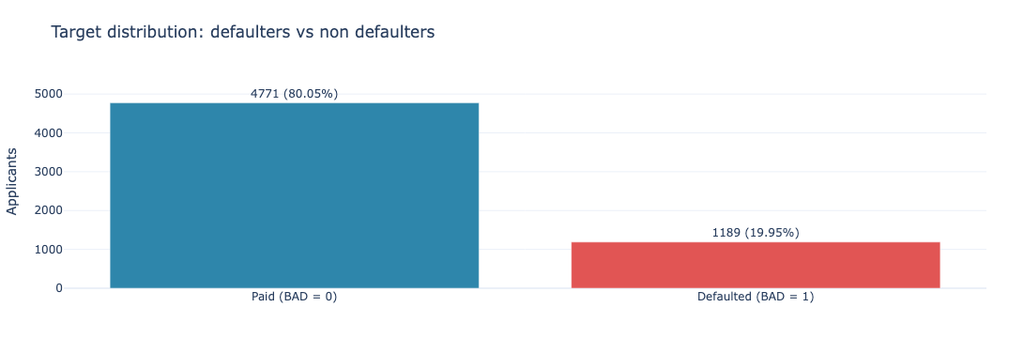

```python
# Target distribution
target_df = (
    df["BAD"]
    .map({0: "Paid (BAD = 0)", 1: "Defaulted (BAD = 1)"})
    .value_counts()
    .reset_index()
)
target_df.columns = ["status", "count"]
target_df["percent"] = (target_df["count"] / target_df["count"].sum() * 100).round(2)

fig = px.bar(
    target_df,
    x="status",
    y="count",
    text=target_df["count"].astype(str) + " (" + target_df["percent"].astype(str) + "%)",
    color="status",
    color_discrete_map={"Paid (BAD = 0)": "#2E86AB", "Defaulted (BAD = 1)": "#E15554"},
    title="Target distribution: defaulters vs non defaulters",
)
fig.update_layout(
    showlegend=False,
    yaxis_title="Applicants",
    xaxis_title="",
    yaxis_range=[0, target_df["count"].max() * 1.15],
    margin=dict(t=80, b=40, l=60, r=40),
)
fig.update_traces(textposition="outside", cliponaxis=False)
save_chart(fig, "sec06_target_distribution")
fig.show()
```

**Key takeaways from the target distribution**

- Class balance
  - 4,771 applicants paid (80.05 percent) and 1,189 defaulted (19.95 percent), giving a moderately imbalanced 80/20 split
- Modeling implications
  - I will stratify the train test split on `BAD` so both sets keep the 80/20 mix, with no oversampling or undersampling needed
- Metric implications
  - Raw accuracy is misleading because predicting "no default" for everyone already scores 80 percent, so I optimize for recall on class 1 with F1 as the tie breaker and ROC AUC as a secondary diagnostic

### 6.2 Numeric Feature Distributions

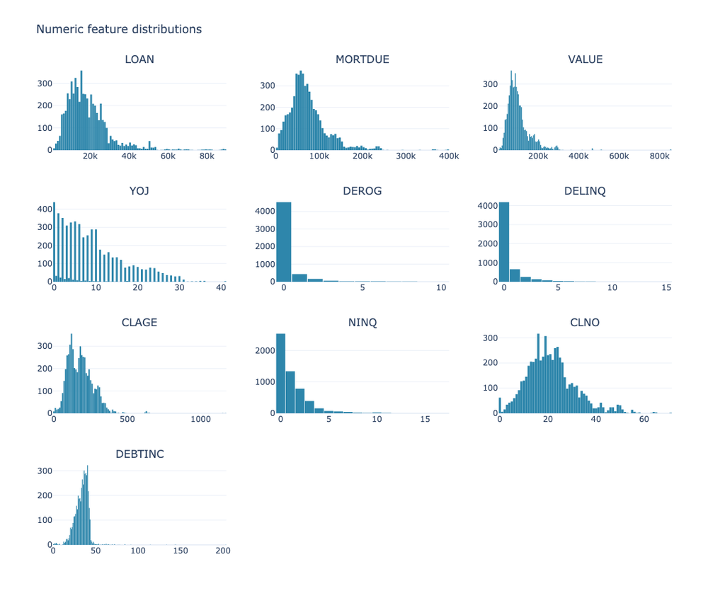

```python
# Numeric feature distributions (small multiples)
numeric_cols = ["LOAN", "MORTDUE", "VALUE", "YOJ", "DEROG", "DELINQ", "CLAGE", "NINQ", "CLNO", "DEBTINC"]

fig = make_subplots(
    rows=4, cols=3,
    subplot_titles=numeric_cols,
    vertical_spacing=0.10,
    horizontal_spacing=0.08,
)
for i, col in enumerate(numeric_cols):
    r, c = divmod(i, 3)
    fig.add_trace(
        go.Histogram(x=df[col].dropna(), marker_color="#2E86AB", showlegend=False),
        row=r + 1, col=c + 1,
    )
fig.update_layout(
    height=900,
    title_text="Numeric feature distributions",
    bargap=0.05,
)
save_chart(fig, "sec06_numeric_distributions")
fig.show()
```

### Takeaways

- **LOAN (loan amount requested in USD):** Right skewed with a long tail; most loans cluster under 25,000 USD but a few reach 90,000 USD. I will log transform or leave as is for tree models and scale for distance/linear models.
- **MORTDUE (amount due on the existing mortgage in USD):** Strong right skew with a heavy tail past 200,000 USD and meaningful missingness. I will median impute, add a missingness flag, and scale for non tree models.
- **VALUE (current value of the property in USD):** Right skewed with a very long tail above 400,000 USD and a few extreme outliers. I will cap or log transform for linear/distance models and keep raw for tree models.
- **YOJ (years at present job):** Right skewed with a spike at 0 and a mode around 2 to 5 years. I will median impute and leave the distribution for tree models.
- **DEROG (number of major derogatory reports):** Extremely zero inflated; almost every applicant has 0 with a thin tail out to about 10. I will impute with 0, add a missingness flag, and consider a binary "has any derogatory" feature.
- **DELINQ (number of delinquent credit lines):** Zero inflated like DEROG with most values at 0 and a thin tail to about 15. I will impute with 0, add a missingness flag, and consider a binary "has any delinquency" feature.
- **CLAGE (age of oldest credit line in months):** Roughly right skewed and centered near 150 to 200 months with a long tail past 600. I will median impute and scale for non tree models.
- **NINQ (number of recent credit inquiries):** Zero inflated with most applicants at 0 to 2 and a tail to about 15. I will median impute and leave as is for tree models.
- **CLNO (number of existing credit lines):** Roughly symmetric around 20 with a mild right tail. Minimal cleaning needed; impute the few missing with the median.
- **DEBTINC (debt to income ratio in percent):** Tight bell near 30 to 40 percent with a few extreme outliers and the highest missingness in the dataset at about 21 percent. I will median impute, add a missingness flag, and cap extreme outliers for linear models.

### 6.3 Categorical Feature Distributions

The two categorical features are `REASON` (why the loan) and `JOB` (what the applicant does for a living).

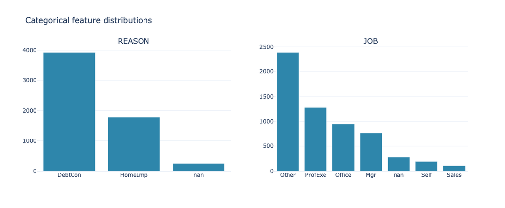

```python
# Categorical feature distributions
fig = make_subplots(rows=1, cols=2, subplot_titles=["REASON", "JOB"])

reason_counts = df["REASON"].value_counts(dropna=False).reset_index()
reason_counts.columns = ["category", "count"]
fig.add_trace(
    go.Bar(x=reason_counts["category"].astype(str), y=reason_counts["count"],
           marker_color="#2E86AB", showlegend=False),
    row=1, col=1,
)

job_counts = df["JOB"].value_counts(dropna=False).reset_index()
job_counts.columns = ["category", "count"]
fig.add_trace(
    go.Bar(x=job_counts["category"].astype(str), y=job_counts["count"],
           marker_color="#2E86AB", showlegend=False),
    row=1, col=2,
)
fig.update_layout(height=450, title_text="Categorical feature distributions")
save_chart(fig, "sec06_categorical_distributions")
fig.show()
```

## 7. Bivariate Analysis

Bivariate means "two variables at a time", with the target always on one side. We want to see which features actually separate defaulters from non defaulters, because those are the features the model will lean on the most.

### 7.1 Numeric Features versus Default

Box plots of each numeric feature split by `BAD`. If the two boxes overlap heavily, the feature has weak signal on its own. If the boxes are pulled apart, the feature is informative.

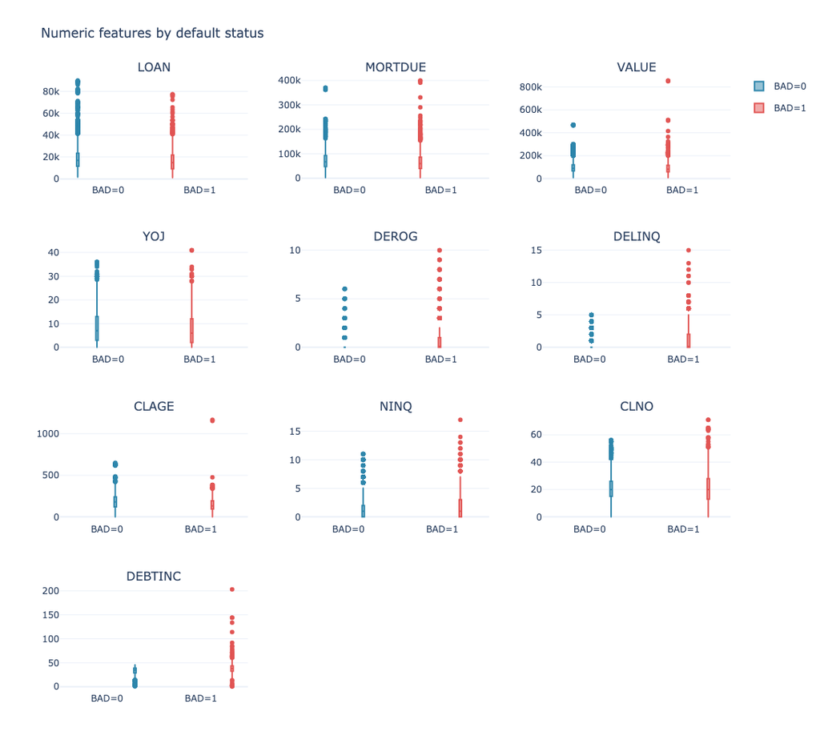

```python
# Box plots of numeric features by BAD
fig = make_subplots(
    rows=4, cols=3,
    subplot_titles=numeric_cols,
    vertical_spacing=0.10,
    horizontal_spacing=0.08,
)
palette = {0: "#2E86AB", 1: "#E15554"}
for i, col in enumerate(numeric_cols):
    r, c = divmod(i, 3)
    for bad_val in [0, 1]:
        fig.add_trace(
            go.Box(
                y=df.loc[df["BAD"] == bad_val, col].dropna(),
                name=f"BAD={bad_val}",
                marker_color=palette[bad_val],
                showlegend=(i == 0),
                legendgroup=f"BAD={bad_val}",
            ),
            row=r + 1, col=c + 1,
        )
fig.update_layout(
    height=1000,
    title_text="Numeric features by default status",
    boxmode="group",
)
save_chart(fig, "sec07_numeric_vs_bad")
fig.show()
```

### Takeaways

- **LOAN (loan amount requested in USD):** Defaulters have a slightly lower median loan amount than non defaulters; overlap is heavy so LOAN alone is a weak signal.
- **MORTDUE (amount due on the existing mortgage in USD):** Distributions look nearly identical across BAD=0 and BAD=1; minimal standalone predictive power.
- **VALUE (current value of the property in USD):** Non defaulters skew slightly higher in property value but the two boxes overlap substantially; weak signal on its own.
- **YOJ (years at present job):** Medians are very close (~7 years for both); YOJ does not separate defaulters from non defaulters by itself.
- **DEROG (number of major derogatory reports):** Defaulters show a clearly wider spread and more high value outliers reaching 10 versus a tight box at 0 for non defaulters; strong predictive signal.
- **DELINQ (number of delinquent credit lines):** Non defaulters cluster at 0 while defaulters have a visibly wider box and outliers up to 15; strong predictive signal.
- **CLAGE (age of oldest credit line in months):** Non defaulters have a meaningfully higher median credit history age; longer credit history is associated with lower default risk.
- **NINQ (number of recent credit inquiries):** Defaulters show a higher median and wider upper tail than non defaulters; more recent inquiries lean toward default.
- **CLNO (number of existing credit lines):** Distributions overlap heavily with similar medians near 20; weak standalone signal.
- **DEBTINC (debt to income ratio in percent):** The most dramatic separation in the chart; defaulters have a much higher median and wider spread with outliers past 200 percent, while non defaulters cluster tightly near 35 percent. This is the strongest single predictor visible in the EDA.

### 7.2 Default Rate by Job

For the categoricals, the interesting number is the **default rate within each category**, not just the count. A category with only 200 applicants but a 35 percent default rate is much more informative than one with 3000 applicants and a 20 percent default rate.

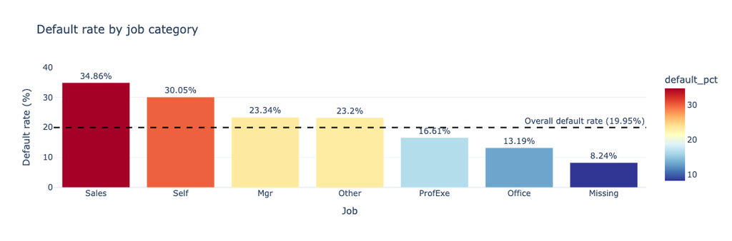

```python
# Default rate by JOB
job_rate = (
    df.groupby("JOB", dropna=False)["BAD"]
    .agg(["mean", "count"])
    .reset_index()
    .rename(columns={"mean": "default_rate", "count": "applicants"})
    .sort_values("default_rate", ascending=False)
)
job_rate["default_pct"] = (job_rate["default_rate"] * 100).round(2)
job_rate["JOB"] = job_rate["JOB"].fillna("Missing").astype(str)
fig = px.bar(
    job_rate,
    x="JOB",
    y="default_pct",
    text=job_rate["default_pct"].astype(str) + "%",
    hover_data=["applicants"],
    color="default_pct",
    color_continuous_scale="RdYlBu_r",
    title="Default rate by job category",
)
fig.add_hline(y=19.95, line_dash="dash", line_color="black",
              annotation_text="Overall default rate (19.95%)", annotation_position="top right")
fig.update_layout(
    yaxis_title="Default rate (%)",
    xaxis_title="Job",
    showlegend=False,
    yaxis_range=[0, job_rate["default_pct"].max() * 1.15],
)
fig.update_traces(textposition="outside", cliponaxis=False)
save_chart(fig, "sec07_default_rate_by_job")
fig.show()
```

### Takeaways

- **Sales:** Highest default rate at roughly 34.9 percent, nearly 15 points above the overall average; small sample size warrants caution but the signal is strong.
- **Self:** Second highest at 30.05 percent, also well above the overall rate; self employed applicants carry elevated risk.
- **Mgr and Other:** Both sit just above the overall rate at 23.34 percent and 23.2 percent respectively; mild risk elevation.
- **ProfExe and Office:** Both fall below the overall rate at 16.61 percent and 13.19 percent; these categories are lower risk.
- **Missing (nan):** Lowest observed default rate at 8.24 percent, which is counterintuitive and suggests missing JOB may correlate with a safer subpopulation; I will keep a missingness indicator rather than drop or collapse.
- **Modeling note:** JOB shows a clear monotonic risk gradient from Sales to Office, making it a useful categorical predictor; I will one hot encode for non tree models and let CatBoost handle it natively.

### 7.3 Default Rate by Reason

Same idea for `REASON`. We are checking whether debt consolidation loans default at a different rate than home improvement loans.

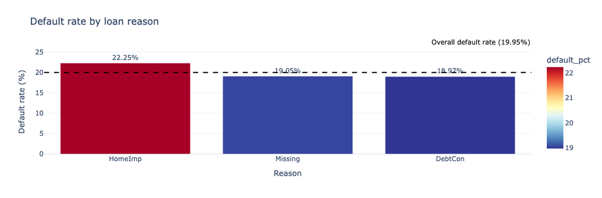

```python
# Default rate by REASON
reason_rate = (
    df.groupby("REASON", dropna=False)["BAD"]
    .agg(["mean", "count"])
    .reset_index()
    .rename(columns={"mean": "default_rate", "count": "applicants"})
    .sort_values("default_rate", ascending=False)
)
reason_rate["default_pct"] = (reason_rate["default_rate"] * 100).round(2)
reason_rate["REASON"] = reason_rate["REASON"].fillna("Missing").astype(str)
fig = px.bar(
    reason_rate,
    x="REASON",
    y="default_pct",
    text=reason_rate["default_pct"].astype(str) + "%",
    hover_data=["applicants"],
    color="default_pct",
    color_continuous_scale="RdYlBu_r",
    title="Default rate by loan reason",
)
fig.add_hline(y=19.95, line_dash="dash", line_color="black")
fig.add_annotation(
    xref="paper", yref="paper",
    x=1.0, y=1.02,
    text="Overall default rate (19.95%)",
    showarrow=False,
    xanchor="right", yanchor="bottom",
    font=dict(color="black"),
)
fig.update_layout(
    yaxis_title="Default rate (%)",
    xaxis_title="Reason",
    showlegend=False,
    yaxis_range=[0, reason_rate["default_pct"].max() * 1.15],
    margin=dict(t=90),
)
fig.update_traces(textposition="outside", cliponaxis=False)
save_chart(fig, "sec07_default_rate_by_reason")
fig.show()
```

### 7.4 Missingness as a Feature

When data is missing, sometimes the missingness itself is a signal. If applicants with a missing `DEBTINC` default at a very different rate than applicants with a reported `DEBTINC`, we should add a missingness indicator column before imputing.

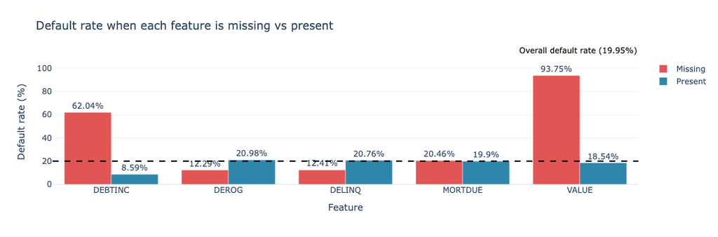

|  | column | default_rate_if_missing | default_rate_if_present | n_missing |
| --- | --- | --- | --- | --- |
| 0 | DEBTINC | 62.04 | 8.59 | 1267 |
| 1 | DEROG | 12.29 | 20.98 | 708 |
| 2 | DELINQ | 12.41 | 20.76 | 580 |
| 3 | MORTDUE | 20.46 | 19.90 | 518 |
| 4 | VALUE | 93.75 | 18.54 | 112 |

```python
# Default rate by whether key features are missing
miss_cols = ["DEBTINC", "DEROG", "DELINQ", "MORTDUE", "VALUE"]
rows = []
for col in miss_cols:
    is_missing = df[col].isna()
    rate_missing = df.loc[is_missing, "BAD"].mean() * 100
    rate_present = df.loc[~is_missing, "BAD"].mean() * 100
    rows.append({"column": col, "default_rate_if_missing": round(rate_missing, 2),
                 "default_rate_if_present": round(rate_present, 2),
                 "n_missing": int(is_missing.sum())})
miss_df = pd.DataFrame(rows)

max_y = max(miss_df["default_rate_if_missing"].max(), miss_df["default_rate_if_present"].max())

fig = go.Figure()
fig.add_trace(go.Bar(name="Missing", x=miss_df["column"], y=miss_df["default_rate_if_missing"],
                     marker_color="#E15554", text=miss_df["default_rate_if_missing"].astype(str) + "%",
                     textposition="outside", cliponaxis=False))
fig.add_trace(go.Bar(name="Present", x=miss_df["column"], y=miss_df["default_rate_if_present"],
                     marker_color="#2E86AB", text=miss_df["default_rate_if_present"].astype(str) + "%",
                     textposition="outside", cliponaxis=False))
fig.add_hline(y=19.95, line_dash="dash", line_color="black")
fig.add_annotation(
    xref="paper", yref="paper",
    x=1.0, y=1.02,
    text="Overall default rate (19.95%)",
    showarrow=False,
    xanchor="right", yanchor="bottom",
    font=dict(color="black"),
)
fig.update_layout(
    title="Default rate when each feature is missing vs present",
    barmode="group",
    yaxis_title="Default rate (%)",
    xaxis_title="Feature",
    yaxis_range=[0, max_y * 1.15],
    margin=dict(t=90),
)
save_chart(fig, "sec07_missingness_vs_bad")
fig.show()
miss_df
```

### Takeaways

- **DEBTINC (debt to income ratio):** Applicants with missing DEBTINC default at 62.04 percent versus 8.59 percent when present, a 53 point gap on 1,267 missing rows. This is the single strongest signal in the entire EDA; I will add a DEBTINC missingness flag as a modeling feature.
- **VALUE (current property value):** Missing VALUE defaults at 93.75 percent versus 18.54 percent when present, a 75 point gap but on only 112 rows. Extreme risk concentration worth encoding as a flag despite the small sample.
- **DEROG (number of major derogatory reports):** Missing DEROG defaults at 12.29 percent versus 20.98 percent when present, an inverse 9 point gap on 708 missing rows. Missingness here correlates with lower risk; I will add a flag.
- **DELINQ (number of delinquent credit lines):** Missing DELINQ defaults at 12.41 percent versus 20.76 percent when present, another inverse 8 point gap on 580 missing rows. Same pattern as DEROG; add a flag.
- **MORTDUE (amount due on the existing mortgage):** Missing and present rates are nearly identical at 20.46 percent and 19.9 percent on 518 missing rows; essentially no signal in missingness alone.
- **Why DEBTINC and VALUE may be missing:** Dallas Fed mortgage research finds that loans with missing or outlier debt to income ratios default at higher rates because missing financial fields signal information gaps that cluster with other risk factors like low credit scores and high loan to value ratios, so lenders treat incomplete documentation as a risk signal rather than random data loss.
- **Modeling note:** Missingness is not random; it is a strong predictor for DEBTINC and VALUE and a moderate inverse predictor for DEROG and DELINQ. I will create binary missingness indicator columns for all five features before imputation so the model can learn from the pattern itself, not just the imputed values.

## 8. Multivariate Analysis

Multivariate means "more than two variables at once". The correlation heatmap tells us which features move together, which matters because highly correlated features can confuse linear models like logistic regression, while tree based models handle it fine.

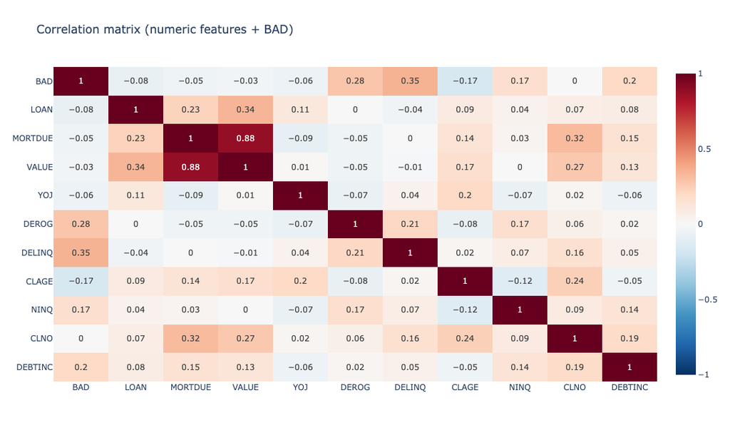

```python
# Correlation heatmap on numeric features plus target
corr_cols = ["BAD"] + numeric_cols
corr = df[corr_cols].corr().round(2)

fig = px.imshow(
    corr,
    text_auto=True,
    color_continuous_scale="RdBu_r",
    zmin=-1, zmax=1,
    aspect="auto",
    title="Correlation matrix (numeric features + BAD)",
)
fig.update_layout(height=650)
save_chart(fig, "sec08_correlation_heatmap")
fig.show()
```

### Takeaways

- **Strongest predictors of BAD (default target):** DELINQ (number of delinquent credit lines) at 0.35 and DEROG (number of major derogatory reports) at 0.28 are the top positive correlations; credit history red flags carry the most linear signal.
- **Secondary predictors of BAD:** DEBTINC (debt to income ratio) at 0.20 and NINQ (number of recent credit inquiries) at 0.17 add moderate positive signal, while CLAGE (age of oldest credit line) at minus 0.17 adds the strongest negative signal; longer credit history lowers risk.
- **Weak or no standalone signal:** LOAN, MORTDUE, VALUE, YOJ, and CLNO all sit between minus 0.08 and 0.0 with BAD; these features will need interactions or nonlinear models to contribute.
- **Multicollinearity warning:** MORTDUE (mortgage balance due) and VALUE (property value) correlate at 0.88, which will inflate variance in linear models. I will either drop one, create a loan to value ratio feature, or rely on tree based models that handle collinearity natively.
- **Secondary collinearity:** MORTDUE and CLNO at 0.32, VALUE and LOAN at 0.34, and VALUE and CLNO at 0.27 are mild but worth noting; not severe enough to act on directly.
- **Modeling note:** Linear correlations alone underestimate feature importance here since DEBTINC showed a massive effect through missingness and the box plots revealed strong nonlinear separation; tree and boosting models should outperform logistic regression on this data.

### 8.1 Features Most Correlated with Default

We pull the correlation with `BAD` out of the matrix and sort to see which numeric features move the most with default status. This is a crude ranking (it only captures linear relationships), but it is a useful first signal.

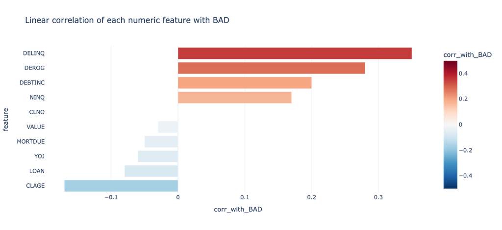

|  | feature | corr_with_BAD |
| --- | --- | --- |
| 0 | DELINQ | 0.35 |
| 1 | DEROG | 0.28 |
| 2 | DEBTINC | 0.20 |
| 3 | CLAGE | -0.17 |
| 4 | NINQ | 0.17 |
| 5 | LOAN | -0.08 |
| 6 | YOJ | -0.06 |
| 7 | MORTDUE | -0.05 |
| 8 | VALUE | -0.03 |
| 9 | CLNO | -0.00 |

```python
# Top correlations with the target
target_corr = corr["BAD"].drop("BAD").sort_values(key=abs, ascending=False)
target_corr_df = target_corr.reset_index()
target_corr_df.columns = ["feature", "corr_with_BAD"]

fig = px.bar(
    target_corr_df,
    x="corr_with_BAD",
    y="feature",
    orientation="h",
    color="corr_with_BAD",
    color_continuous_scale="RdBu_r",
    range_color=[-0.5, 0.5],
    title="Linear correlation of each numeric feature with BAD",
)
fig.update_layout(yaxis={"categoryorder": "total ascending"}, height=500, showlegend=False)
save_chart(fig, "sec08_top_correlations_with_bad")
fig.show()

target_corr_df
```

## 9. EDA Takeaways

This section summarizes what I learned from the EDA in plain English and sets the direction for preprocessing and modeling.

**Target balance:**

- 19.95 percent of applicants defaulted (BAD = 1) versus 80.05 percent who paid, so the problem is moderately imbalanced. I will optimize for recall on class 1 (defaulters) rather than raw accuracy, with F1 as the tie breaker.

**Strongest individual predictors:**

- **DELINQ (number of delinquent credit lines):** Highest linear correlation with BAD at 0.35 and dramatic box plot separation; the single strongest numeric predictor.
- **DEROG (number of major derogatory reports):** Second strongest at 0.28 with the same pattern of zero inflation for non defaulters and a long tail for defaulters.
- **DEBTINC (debt to income ratio in percent):** Correlation of 0.20 when present, but the missingness signal is far stronger; applicants with missing DEBTINC default at 62.04 percent versus 8.59 percent when present.
- **CLAGE (age of oldest credit line in months):** Strongest negative correlation at minus 0.17; longer credit history is protective.
- **JOB (applicant's job category):** Clear monotonic risk gradient from Sales at 34.9 percent default down to Office at 13.2 percent, making it the strongest categorical predictor.

**Data quality issues that drive preprocessing:**

- **DEBTINC missingness (21.3 percent):** Not random. Dallas Fed mortgage research confirms that missing debt to income fields correlate with other risk factors like low credit scores and high loan to value ratios, so lenders treat incomplete documentation as a risk signal. I will add a missingness indicator before imputation.
- **VALUE missingness (1.9 percent):** Only 112 rows but a 93.75 percent default rate when missing versus 18.54 percent when present; extreme risk concentration worth flagging.
- **DEROG and DELINQ missingness (11.9 and 9.7 percent):** Inverse relationship. Missing values correlate with lower default rates (12.3 and 12.4 percent versus 21.0 and 20.8 percent when present), suggesting these fields are only populated when issues exist. I will add missingness flags for both.
- **MORTDUE missingness (8.7 percent):** No meaningful signal in missingness alone, but I will add a flag for consistency.
- **Dollar features (LOAN, MORTDUE, VALUE):** Right skewed with extreme outliers past the 99th percentile. I will cap at the 99th percentile before scaling for linear and distance based models; tree models can use raw values.
- **MORTDUE and VALUE collinearity at 0.88:** Will inflate variance in linear models. I will either drop one, engineer a loan to value ratio feature, or rely on tree based models that handle collinearity natively.

**Implications for modeling:**

## 10. Outlier Treatment

The dollar features (`LOAN`, `MORTDUE`, `VALUE`) and the debt to income ratio (`DEBTINC`) are right skewed with a few extreme values that pull the distribution tails out past the 99th percentile. Linear and distance based models are sensitive to those tails, so I cap each feature at its 1st and 99th percentile. Tree based models are not sensitive to capping so the same treatment is safe to use across all models.

- I cap rather than drop because dropping outlier rows would throw away real defaulters.
- I cap at the 1st/99th percentile rather than IQR because the right tail here is long and the IQR rule would flag too many rows.

```python
# Work on a copy so the original df stays intact for reference
df_proc = df.copy()

cap_cols = ["LOAN", "MORTDUE", "VALUE", "DEBTINC"]

cap_report = []
for col in cap_cols:
    lo = df_proc[col].quantile(0.01)
    hi = df_proc[col].quantile(0.99)
    n_capped_lo = int((df_proc[col] < lo).sum())
    n_capped_hi = int((df_proc[col] > hi).sum())
    df_proc[col] = df_proc[col].clip(lower=lo, upper=hi)
    cap_report.append({
        "feature": col,
        "p01": round(lo, 2),
        "p99": round(hi, 2),
        "n_capped_low": n_capped_lo,
        "n_capped_high": n_capped_hi,
    })

pd.DataFrame(cap_report)
```

|  | feature | p01 | p99 | n_capped_low | n_capped_high |
| --- | --- | --- | --- | --- | --- |
| 0 | LOAN | 3359.00 | 60869.00 | 60 | 60 |
| 1 | MORTDUE | 7855.40 | 232230.41 | 55 | 55 |
| 2 | VALUE | 26262.20 | 289962.80 | 59 | 59 |
| 3 | DEBTINC | 13.28 | 49.22 | 47 | 47 |

### Section 10 — Outlier capping report

- I capped 60 extreme values on each side for LOAN, 55 for MORTDUE, 59 for VALUE, and 47 for DEBTINC (about 1 percent of the 5,960 rows on each tail, exactly as intended) so the dollar tails no longer distort linear and distance based models; no changes needed.

## 11. Missing Value Treatment

The EDA showed that missingness itself is a signal for `DEBTINC`, `VALUE`, `DEROG`, and `DELINQ`. I add a binary missingness indicator column for each of the five features with meaningful missing counts before I impute, so the model can learn from the pattern directly rather than only from the imputed value.

- Numeric features: median imputation inside the pipeline.
- Categorical features (`REASON`, `JOB`): explicit "Missing" category so the model treats it as its own level.

```python
# Add binary missingness indicators before imputation so the signal is preserved
flag_cols = ["DEBTINC", "VALUE", "DEROG", "DELINQ", "MORTDUE"]
for col in flag_cols:
    df_proc[f"{col}_missing"] = df_proc[col].isna().astype(int)

# Fill categorical NaN with explicit "Missing" category
for col in ["REASON", "JOB"]:
    df_proc[col] = df_proc[col].fillna("Missing")

print(f"Added {len(flag_cols)} missingness indicator columns: {[f + '_missing' for f in flag_cols]}")
print(f"Shape after adding flags: {df_proc.shape}")
df_proc.head()
```

```
Added 5 missingness indicator columns: ['DEBTINC_missing', 'VALUE_missing', 'DEROG_missing', 'DELINQ_missing', 'MORTDUE_missing']
Shape after adding flags: (5960, 18)
```

|  | BAD | LOAN | MORTDUE | VALUE | REASON | JOB | YOJ | DEROG | DELINQ | CLAGE | NINQ | CLNO | DEBTINC | DEBTINC_missing | VALUE_missing | DEROG_missing | DELINQ_missing | MORTDUE_missing |
| --- | --- | --- | --- | --- | --- | --- | --- | --- | --- | --- | --- | --- | --- | --- | --- | --- | --- | --- |
| 0 | 1 | 3359 | 25860.0 | 39025.0 | HomeImp | Other | 10.5 | 0.0 | 0.0 | 94.366667 | 1.0 | 9.0 | NaN | 1 | 0 | 0 | 0 | 0 |
| 1 | 1 | 3359 | 70053.0 | 68400.0 | HomeImp | Other | 7.0 | 0.0 | 2.0 | 121.833333 | 0.0 | 14.0 | NaN | 1 | 0 | 0 | 0 | 0 |
| 2 | 1 | 3359 | 13500.0 | 26262.2 | HomeImp | Other | 4.0 | 0.0 | 0.0 | 149.466667 | 1.0 | 10.0 | NaN | 1 | 0 | 0 | 0 | 0 |
| 3 | 1 | 3359 | NaN | NaN | Missing | Missing | NaN | NaN | NaN | NaN | NaN | NaN | NaN | 1 | 1 | 1 | 1 | 1 |
| 4 | 0 | 3359 | 97800.0 | 112000.0 | HomeImp | Office | 3.0 | 0.0 | 0.0 | 93.333333 | 0.0 | 14.0 | NaN | 1 | 0 | 0 | 0 | 0 |

### Section 11 — Missingness indicator columns

- Added 5 new flag columns bringing the frame to 18 columns and I can see the flags correctly fire for row 3 which is missing almost every field; no changes needed since imputation happens later inside the pipeline.

## 12. Encoding and Scaling

I build two preprocessing pipelines via `ColumnTransformer` so every model gets exactly the preparation it needs.

- **Linear/distance pipeline (`prep_linear`):** median impute numerics, standard scale, one hot encode `REASON` and `JOB`. Used by Logistic Regression, KNN, Naive Bayes, LDA, QDA, SVM, and MLP.
- **Tree pipeline (`prep_tree`):** median impute numerics, one hot encode categoricals, no scaling. Used by Decision Tree, Random Forest, Bagging, AdaBoost, Gradient Boosting, XGBoost, and LightGBM. CatBoost uses its own native categorical handling outside these pipelines.

```python
from sklearn.compose import ColumnTransformer
from sklearn.impute import SimpleImputer
from sklearn.pipeline import Pipeline
from sklearn.preprocessing import StandardScaler, OneHotEncoder

# Feature lists
TARGET = "BAD"
numeric_features = [
    "LOAN", "MORTDUE", "VALUE", "YOJ", "DEROG", "DELINQ",
    "CLAGE", "NINQ", "CLNO", "DEBTINC",
] + [f"{c}_missing" for c in flag_cols]
categorical_features = ["REASON", "JOB"]

# Linear/distance preprocessing: impute, scale, one hot
prep_linear = ColumnTransformer([
    ("num", Pipeline([
        ("impute", SimpleImputer(strategy="median")),
        ("scale", StandardScaler()),
    ]), numeric_features),
    ("cat", OneHotEncoder(handle_unknown="ignore"), categorical_features),
])

# Tree preprocessing: impute and one hot, no scaling
prep_tree = ColumnTransformer([
    ("num", SimpleImputer(strategy="median"), numeric_features),
    ("cat", OneHotEncoder(handle_unknown="ignore"), categorical_features),
])

print(f"Numeric features ({len(numeric_features)}): {numeric_features}")
print(f"Categorical features ({len(categorical_features)}): {categorical_features}")
```

```
Numeric features (15): ['LOAN', 'MORTDUE', 'VALUE', 'YOJ', 'DEROG', 'DELINQ', 'CLAGE', 'NINQ', 'CLNO', 'DEBTINC', 'DEBTINC_missing', 'VALUE_missing', 'DEROG_missing', 'DELINQ_missing', 'MORTDUE_missing']
Categorical features (2): ['REASON', 'JOB']
```

## 13. Train / Test Split

I split the processed frame into a 75/25 train/test split, stratified on `BAD` so the default rate is preserved in both pieces. Stratification matters here because the target is imbalanced and a random split could easily land too few defaulters in either set.

```python
from sklearn.model_selection import train_test_split

X = df_proc.drop(columns=[TARGET])
y = df_proc[TARGET]

X_train, X_test, y_train, y_test = train_test_split(
    X, y,
    test_size=0.25,
    stratify=y,
    random_state=RANDOM_STATE,
)

print(f"Train shape: {X_train.shape}, Test shape: {X_test.shape}")
print(f"Train default rate: {y_train.mean():.4f}")
print(f"Test default rate:  {y_test.mean():.4f}")
```

```
Train shape: (4470, 17), Test shape: (1490, 17)
Train default rate: 0.1996
Test default rate:  0.1993
```

### Section 13 — Train/test split

- Training set has 4,470 rows and test has 1,490 rows with default rates of 19.96 and 19.93 percent, so stratification preserved the class balance almost exactly between the two sets; no changes needed.

## 14. Modeling Approach and Helper Functions

Every classifier is fit through a shared helper so each row in the final comparison table is calculated the exact same way.

- **Primary metric: Recall on class 1 (defaulters).** Missing a defaulter costs a full loan; rejecting a good applicant costs only a fee and a lost relationship.
- **Tie breakers:** F1 on class 1, then ROC AUC, then PR AUC.
- **Two helpers:**
  - `evaluate_model` scores a single fitted model on the held out test set. Used for methods where tuning buys nothing (Logistic Regression, Naive Bayes, LDA, QDA).
  - `tune_and_evaluate` runs 5 fold stratified `GridSearchCV` optimized on recall, then scores the best estimator on the test set. Used for every method with meaningful hyperparameters (KNN, Decision Tree, Random Forest, Bagging, AdaBoost, Gradient Boosting, XGBoost, LightGBM, CatBoost, SVM, MLP).
- **Class imbalance handling:** `class_weight="balanced"` (or `scale_pos_weight` for gradient boosters) gives the minority class a fair shot inside every fold.

```python
import warnings
warnings.filterwarnings("ignore")

from sklearn.metrics import (
    accuracy_score, precision_score, recall_score, f1_score,
    roc_auc_score, average_precision_score, confusion_matrix,
)
from sklearn.model_selection import StratifiedKFold, GridSearchCV

# Container that each model appends its metrics to
results = []

# Shared stratified 5 fold CV object; reused by every tuned model below
CV_SPLITS = 5
cv = StratifiedKFold(n_splits=CV_SPLITS, shuffle=True, random_state=RANDOM_STATE)


def evaluate_model(name, model, X_test, y_test, results_list, show_plots=True, cv_recall=None):
    """Score a fitted model on the test set and append a metrics row."""
    y_pred = model.predict(X_test)
    if hasattr(model, "predict_proba"):
        y_score = model.predict_proba(X_test)[:, 1]
    elif hasattr(model, "decision_function"):
        y_score = model.decision_function(X_test)
    else:
        y_score = y_pred

    row = {
        "model": name,
        "accuracy": round(accuracy_score(y_test, y_pred), 4),
        "precision_1": round(precision_score(y_test, y_pred, zero_division=0), 4),
        "recall_1": round(recall_score(y_test, y_pred), 4),
        "f1_1": round(f1_score(y_test, y_pred), 4),
        "roc_auc": round(roc_auc_score(y_test, y_score), 4),
        "pr_auc": round(average_precision_score(y_test, y_score), 4),
        "cv_recall": round(cv_recall, 4) if cv_recall is not None else None,
    }
    results_list.append(row)

    print(f"=== {name} ===")
    print(pd.DataFrame([row]).to_string(index=False))
    print()
    print("Confusion matrix (rows = actual, cols = predicted):")
    cm = confusion_matrix(y_test, y_pred)
    cm_df = pd.DataFrame(cm, index=["Paid (0)", "Default (1)"], columns=["Pred 0", "Pred 1"])
    print(cm_df.to_string())
    print()

    if show_plots:
        fig = go.Figure(data=go.Heatmap(
            z=cm,
            x=["Pred 0", "Pred 1"],
            y=["Paid (0)", "Default (1)"],
            colorscale="Blues",
            text=cm,
            texttemplate="%{text}",
            showscale=False,
        ))
        fig.update_layout(
            title=f"Confusion matrix — {name}",
            xaxis_title="Predicted",
            yaxis_title="Actual",
            height=350,
        )
        fig.show()

    return row


def tune_and_evaluate(name, estimator, param_grid, X_train, y_train, X_test, y_test, results_list):
    """Run GridSearchCV with 5 fold stratified CV on recall, then score on test."""
    grid = GridSearchCV(
        estimator=estimator,
        param_grid=param_grid,
        scoring="recall",
        cv=cv,
        n_jobs=-1,
        refit=True,
        verbose=0,
    )
    grid.fit(X_train, y_train)
    print(f"[{name}] best CV recall: {grid.best_score_:.4f}")
    print(f"[{name}] best params: {grid.best_params_}")
    print()
    return evaluate_model(
        name, grid.best_estimator_, X_test, y_test, results_list,
        cv_recall=grid.best_score_,
    )
```

## 15. Logistic Regression

**What it is:**

- A linear model that estimates the log odds of default as a weighted sum of features; interpretable, fast, and a standard baseline.

**Why it is relevant here:**

- If a simple linear model already separates defaulters well, I do not need the complexity of ensembles; `class_weight="balanced"` also gives the minority class a fair shot.

```
=== Logistic Regression ===
              model  accuracy  precision_1  recall_1   f1_1  roc_auc  pr_auc cv_recall
Logistic Regression     0.843       0.5797     0.771 0.6618   0.8895  0.7646      None

Confusion matrix (rows = actual, cols = predicted):
             Pred 0  Pred 1
Paid (0)       1027     166
Default (1)      68     229
```

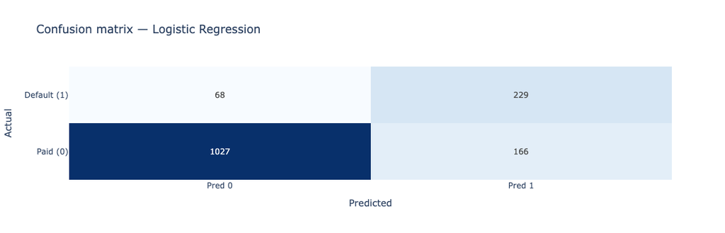

```
{'model': 'Logistic Regression',
 'accuracy': 0.843,
 'precision_1': 0.5797,
 'recall_1': 0.771,
 'f1_1': 0.6618,
 'roc_auc': 0.8895,
 'pr_auc': 0.7646,
 'cv_recall': None}
```

```python
from sklearn.linear_model import LogisticRegression

name = "Logistic Regression"
model = Pipeline([
    ("prep", prep_linear),
    ("clf", LogisticRegression(
        class_weight="balanced",
        max_iter=2000,
        random_state=RANDOM_STATE,
    )),
])
model.fit(X_train, y_train)
evaluate_model(name, model, X_test, y_test, results)
```

### Results

- Logistic Regression caught 229 of 297 actual defaulters for a recall of 77.1 percent at the cost of 166 false alarms on paid loans, with an ROC AUC of 0.89 which is a strong baseline for the rest of the models to beat.
- Precision on class 1 is only 58 percent so roughly 4 in 10 flagged applicants would actually have paid, but that trade off is acceptable given my primary metric is recall and missing a defaulter is the costlier error.
- No changes needed here; I will keep the baseline as is and let the ensembles try to improve on this recall without collapsing precision.

## 16. K Nearest Neighbors

**What it is:**

- A distance based model that predicts the class of an applicant by looking at the K closest points in the training set and taking a vote.

**Why it is relevant here:**

- KNN is non parametric so it does not assume a linear boundary; I tune K and the weighting scheme with 5 fold stratified CV optimized on recall.

```
[K Nearest Neighbors] best CV recall: 0.6031
[K Nearest Neighbors] best params: {'clf__n_neighbors': 5, 'clf__weights': 'distance'}

=== K Nearest Neighbors ===
              model  accuracy  precision_1  recall_1   f1_1  roc_auc  pr_auc  cv_recall
K Nearest Neighbors    0.8993       0.8585    0.5926 0.7012   0.9099  0.7997     0.6031

Confusion matrix (rows = actual, cols = predicted):
             Pred 0  Pred 1
Paid (0)       1164      29
Default (1)     121     176
```

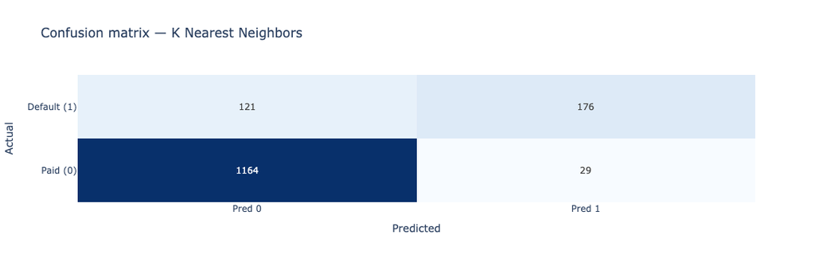

```
{'model': 'K Nearest Neighbors',
 'accuracy': 0.8993,
 'precision_1': 0.8585,
 'recall_1': 0.5926,
 'f1_1': 0.7012,
 'roc_auc': 0.9099,
 'pr_auc': 0.7997,
 'cv_recall': 0.6031}
```

```python
from sklearn.neighbors import KNeighborsClassifier

name = "K Nearest Neighbors"
pipe = Pipeline([
    ("prep", prep_linear),
    ("clf", KNeighborsClassifier(n_jobs=-1)),
])
param_grid = {
    "clf__n_neighbors": [5, 15, 25, 51],
    "clf__weights": ["uniform", "distance"],
}
tune_and_evaluate(name, pipe, param_grid, X_train, y_train, X_test, y_test, results)
```

### Why KNN underperformed compared to Logistic Regression

- **It treats every neighbor the same even when defaulters are rare.** In this dataset 4 out of 5 applicants paid, so when KNN looks at the closest 5 training points (which is what CV picked) to decide, most of the neighbors around any new applicant are "paid" simply because paid applicants dominate the whole space. Even with distance weighting giving closer neighbors more say, a weighted vote over those neighbors still lands on "paid" most of the time, so the model quietly plays it safe and misses real defaulters.
- **Distance does not know which features matter most.** KNN treats a one unit move in DELINQ as equally important as a one unit move in CLAGE after scaling, but the actual risk signal is concentrated in a handful of columns (delinquencies, derogatory marks, missing DEBTINC). Logistic Regression can down-weight the noisy columns with its coefficients; KNN cannot, so the signal gets diluted by columns that do not matter.
- **The missingness flags blur neighbors together.** I added five binary missingness flags that are very predictive on their own, but because they are 0/1 they barely move distances in a space dominated by continuous scaled features. Logistic Regression assigns them real coefficients and uses them directly; KNN basically ignores them.
- **`class_weight="balanced"` does not exist for KNN.** Logistic Regression (and the trees later on) can be told explicitly that a defaulter costs more than a paid applicant, so the decision boundary shifts toward catching defaulters. KNN has no equivalent lever, so even the tuned K=5 distance weighted vote stays unfair to the minority class.
- **Ranking is fine, classifying is not.** The ROC AUC of 0.91 means KNN is actually ordering applicants by risk reasonably well; the problem is purely at the decision threshold, which is why its recall lags even though its AUC is competitive.

## 17. Gaussian Naive Bayes

**What it is:**

- A probabilistic classifier that assumes each feature is Gaussian and conditionally independent given the class, then applies Bayes' rule.

**Why it is relevant here:**

- It is very fast and sets a simple probabilistic floor for the more sophisticated models to beat; the independence assumption is definitely violated (MORTDUE and VALUE are correlated, for example) but it is still informative as a reference.

```
=== Gaussian Naive Bayes ===
               model  accuracy  precision_1  recall_1   f1_1  roc_auc  pr_auc cv_recall
Gaussian Naive Bayes    0.8416       0.6178    0.5387 0.5755   0.8237  0.6285      None

Confusion matrix (rows = actual, cols = predicted):
             Pred 0  Pred 1
Paid (0)       1094      99
Default (1)     137     160
```

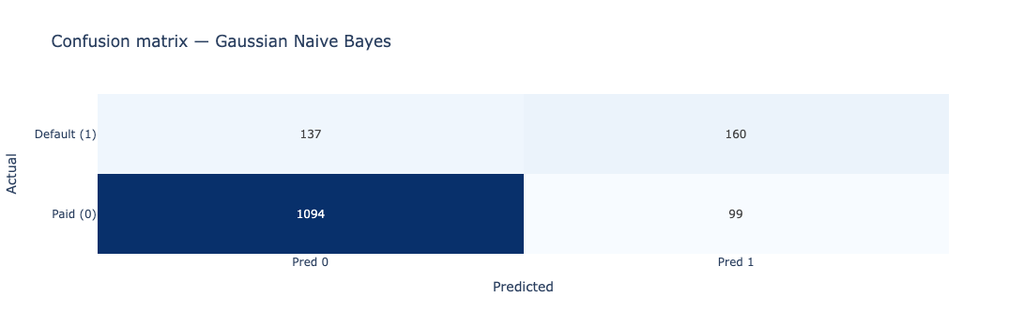

```
{'model': 'Gaussian Naive Bayes',
 'accuracy': 0.8416,
 'precision_1': 0.6178,
 'recall_1': 0.5387,
 'f1_1': 0.5755,
 'roc_auc': 0.8237,
 'pr_auc': 0.6285,
 'cv_recall': None}
```

```python
from sklearn.naive_bayes import GaussianNB

name = "Gaussian Naive Bayes"
model = Pipeline([
    ("prep", prep_linear),
    ("clf", GaussianNB()),
])
model.fit(X_train, y_train)
evaluate_model(name, model, X_test, y_test, results)
```

## 18. Linear Discriminant Analysis

**What it is:**

- A linear model that assumes each class is drawn from a Gaussian with a shared covariance matrix; it finds the linear boundary that maximizes class separation.

**Why it is relevant here:**

- LDA and Logistic Regression often produce similar boundaries; comparing them is a useful sanity check on whether the linear assumption is reasonable for this dataset.

```
=== Linear Discriminant Analysis ===
                       model  accuracy  precision_1  recall_1   f1_1  roc_auc  pr_auc cv_recall
Linear Discriminant Analysis    0.8745         0.72    0.6061 0.6581   0.8874  0.7607      None

Confusion matrix (rows = actual, cols = predicted):
             Pred 0  Pred 1
Paid (0)       1123      70
Default (1)     117     180
```

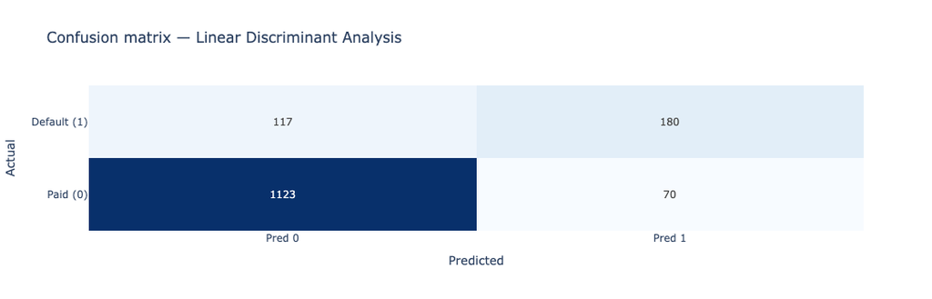

```
{'model': 'Linear Discriminant Analysis',
 'accuracy': 0.8745,
 'precision_1': 0.72,
 'recall_1': 0.6061,
 'f1_1': 0.6581,
 'roc_auc': 0.8874,
 'pr_auc': 0.7607,
 'cv_recall': None}
```

```python
from sklearn.discriminant_analysis import LinearDiscriminantAnalysis

name = "Linear Discriminant Analysis"
model = Pipeline([
    ("prep", prep_linear),
    ("clf", LinearDiscriminantAnalysis()),
])
model.fit(X_train, y_train)
evaluate_model(name, model, X_test, y_test, results)
```

### Results

- Linear Discriminant Analysis caught 180 of 297 actual defaulters for a recall of 60.6 percent, better than KNN and Naive Bayes but still well below Logistic Regression's 77.1 percent, because LDA does not have a `class_weight="balanced"` lever and the shared covariance assumption smooths over real differences between paid and default applicants.
- Precision on class 1 is 72.0 percent with only 70 false alarms on paid loans, so LDA is more surgical than Logistic Regression but catches 49 fewer defaulters — the classic precision versus recall trade off where LDA picks precision.
- ROC AUC of 0.89 is essentially tied with Logistic Regression's 0.89, which confirms LDA's ranking is strong and the whole gap in recall comes from where it plants the decision threshold, not from the quality of the underlying scores.
- No code changes needed; LDA is a closed form method with nothing meaningful to tune, and its job here is to sanity check the linear assumption — that check passes since the ROC AUC matches Logistic Regression almost exactly.

## 19. Quadratic Discriminant Analysis

**What it is:**

- Like LDA but allows each class to have its own covariance matrix, producing a quadratic decision boundary.

**Why it is relevant here:**

- If defaulters and non defaulters have genuinely different spreads in feature space, QDA can capture that where LDA cannot; it is still a closed form method so there is nothing meaningful to tune.

```
=== Quadratic Discriminant Analysis ===
                          model  accuracy  precision_1  recall_1   f1_1  roc_auc  pr_auc cv_recall
Quadratic Discriminant Analysis    0.7617       0.4396    0.7104 0.5431   0.8006  0.5917      None

Confusion matrix (rows = actual, cols = predicted):
             Pred 0  Pred 1
Paid (0)        924     269
Default (1)      86     211
```

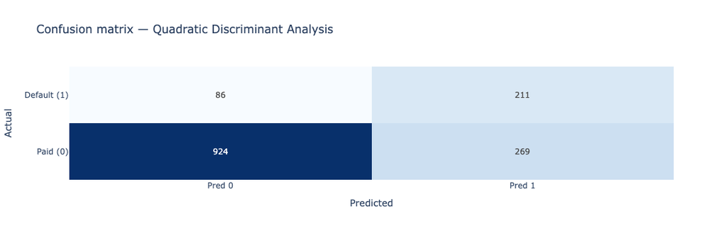

```
{'model': 'Quadratic Discriminant Analysis',
 'accuracy': 0.7617,
 'precision_1': 0.4396,
 'recall_1': 0.7104,
 'f1_1': 0.5431,
 'roc_auc': 0.8006,
 'pr_auc': 0.5917,
 'cv_recall': None}
```

```python
from sklearn.discriminant_analysis import QuadraticDiscriminantAnalysis

name = "Quadratic Discriminant Analysis"
model = Pipeline([
    ("prep", prep_linear),
    ("clf", QuadraticDiscriminantAnalysis()),
])
model.fit(X_train, y_train)
evaluate_model(name, model, X_test, y_test, results)
```